# Lab 1 - Gapminder Data Visualization

Author

Shreya Vanaki

```python
# Import necessary library and packages
import numpy as np
import pandas as pd
import plotnine as p9
from plotnine import ggplot, aes, geom_point, labs, theme_light, scale_x_continuous, scale_y_continuous, geom_bar, geom_boxplot, geom_density, geom_col, position_dodge
import warnings
```

## **Task 1**

**Part 1: Identify, and list here, what aesthetics are being used and which variables are being mapped to each aesthetic.**

The following aesthetics are being used: position i.e x and y, size, fill and annotation. In this case, the income variable is mapped by the x aesthetic, the life expectancy variable is mapped by the y aesthetic, the world’s continents characterized by the four regions variable: Asia, Europe, Africa, and the Americas are mapped by the fill aesthetic. Lastly the population variable is mapped by the size aesthetic.

**Part 2: Import the q1data.csv dataset.**

```python
# Import the dataset provided
df_q1 = pd.read_csv("q1data.csv")

# drop the rows containing null values
df_q1.dropna(inplace = True)
df_q1
```

|  | income | life_exp | population | year | country | four_regions | six_regions | eight_regions | world_bank_region |
| --- | --- | --- | --- | --- | --- | --- | --- | --- | --- |
| 0 | 1910.0 | 61.0 | 29200000.0 | 2010 | Afghanistan | asia | south_asia | asia_west | South Asia |
| 1 | 11100.0 | 78.1 | 2950000.0 | 2010 | Albania | europe | europe_central_asia | europe_east | Europe & Central Asia |
| 2 | 11100.0 | 74.7 | 36000000.0 | 2010 | Algeria | africa | middle_east_north_africa | africa_north | Middle East & North Africa |
| 3 | 46900.0 | 81.9 | 84500.0 | 2010 | Andorra | europe | europe_central_asia | europe_west | Europe & Central Asia |
| 4 | 7680.0 | 60.8 | 23400000.0 | 2010 | Angola | africa | sub_saharan_africa | africa_sub_saharan | Sub-Saharan Africa |
| ... | ... | ... | ... | ... | ... | ... | ... | ... | ... |
| 192 | 20400.0 | 75.4 | 28400000.0 | 2010 | Venezuela | americas | america | america_south | Latin America & Caribbean |
| 193 | 5350.0 | 73.3 | 88000000.0 | 2010 | Vietnam | asia | east_asia_pacific | east_asia_pacific | East Asia & Pacific |
| 194 | 4700.0 | 67.8 | 23200000.0 | 2010 | Yemen | asia | middle_east_north_africa | asia_west | Middle East & North Africa |
| 195 | 3200.0 | 57.5 | 13600000.0 | 2010 | Zambia | africa | sub_saharan_africa | africa_sub_saharan | Sub-Saharan Africa |
| 196 | 2560.0 | 54.4 | 12700000.0 | 2010 | Zimbabwe | africa | sub_saharan_africa | africa_sub_saharan | Sub-Saharan Africa |

191 rows × 9 columns

**Part 3: Recreate the plot as best you can using plotnine.**

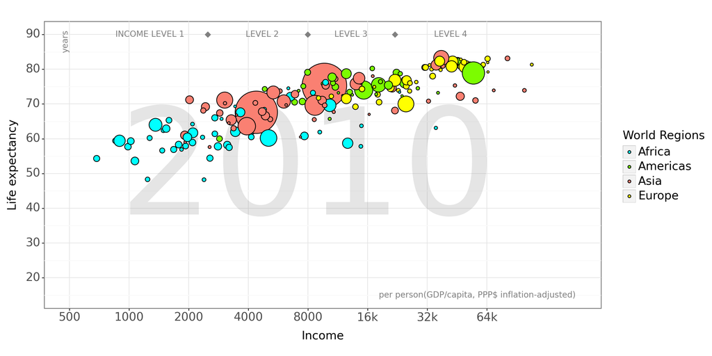

```
<Figure Size: (1200 x 600)>
```

```python
#Create the scatter plot and store it in a object
scatter_plot1 = (p9.ggplot(df_q1, mapping = p9.aes(x='income', y='life_exp', fill ='four_regions', size='population'))


        # Annotations specified to add text and shapes to the scatterplot
        + p9.annotate("text", x = 180000, y = 15, label ="per person(GDP/capita, PPP$ inflation-adjusted)", color = "grey", size = 10, ha = "right")
        + p9.annotate("text", x = 500, y = 88, label = "years", color ="grey", size = 10, ha = "right", angle = 90)
        + p9.annotate("text", x = 8000, y = 50, label = "2010", color = "grey", size = 180, alpha = 0.2)
        + p9.annotate("text", x = 1900, y = 90, label = "INCOME LEVEL 1", color = "grey", size = 10, ha = "right")
        + p9.annotate("text", x = 5700, y = 90, label = "LEVEL 2", color = "grey", size = 10, ha = "right")
        + p9.annotate("text", x = 16000, y = 90, label = "LEVEL 3", color = "grey", size = 10, ha = "right")
        + p9.annotate("text", x = 51000, y = 90, label = "LEVEL 4", color = "grey", size = 10, ha = "right")
        + p9.annotate("text", x = 2500, y = 90, label = "◆", color = "grey", size = 10, ha = "center", va = 'center')
        + p9.annotate("text", x = 8000, y = 90, label = "◆", color = "grey", size = 10, ha = "center", va = 'center')
        + p9.annotate("text", x = 22000, y = 90, label = "◆", color = "grey", size = 10, ha = "center", va = 'center')



        # Plot with alpha defined for transparency of points plotted
        + p9.geom_point(alpha = 1)

        + p9.labs(x ='Income',
                  y ='Life expectancy',
                  fill ='World Regions',
                  size ='Population')


        # Labels, themes and colors specified
        + p9.labs(x ='Income', y ='Life expectancy',fill ='World Regions',size ='Population')
        + p9.theme_bw()
        + p9.theme(text = p9.element_text(size = 14), figure_size = (12, 6))
        + p9.guides(size = False, color = "World Regions")
        + p9.scale_fill_manual(values = {"africa": "aqua","asia": "salmon","americas": "lawngreen", "europe": "yellow"},
                               labels = {"africa": "Africa", "asia": "Asia", "americas": "Americas", "europe": "Europe"})
        + p9.scale_size(range=(1, 30))


        # Breaks and Labels of axes
        + p9.scale_x_continuous(breaks = [500, 1000, 2000, 4000, 8000, 16000, 32000, 64000],
                                labels = ["500", "1000", "2000", "4000", "8000", "16k", "32k", "64k"],
                                 trans = 'log' , limits = (500, 180000))
        + p9.scale_y_continuous(breaks = [20, 30, 40, 50, 60, 70, 80, 90],
                                labels = ["20", "30", "40", "50", "60", "70", "80", "90"],limits = (15,90))
        )

#Print/display Scatterplot created
scatter_plot1
```

Reference: https://coderzcolumn.com/tutorials/data-science/plotnine-annotations

**Part 4: What other geometries could you use here besides geom_point? Provide an actual plot of another geometry being used here and why it’s good or bad for visualizing these data.**

Another geometry that can be used other than geom_point is the line plot style-geometry which I used below. After viewing the dataset and our variables,‘income’, ‘life_exp’, ‘four_regions’, and ‘population’, I think a scatterplot is more suitable to visualize the relationship between income and life expectancy, which are both continuous variables since, scatterplots are meant especially for this purpose and with added aesthetics like filled color for regions and size for population, they can help better represent multi-dimensional data. A line plot might also be suitable if we wanted to observe the trend over a certain period of time between the two variables or the data had a time series format as seen in the visualization below.

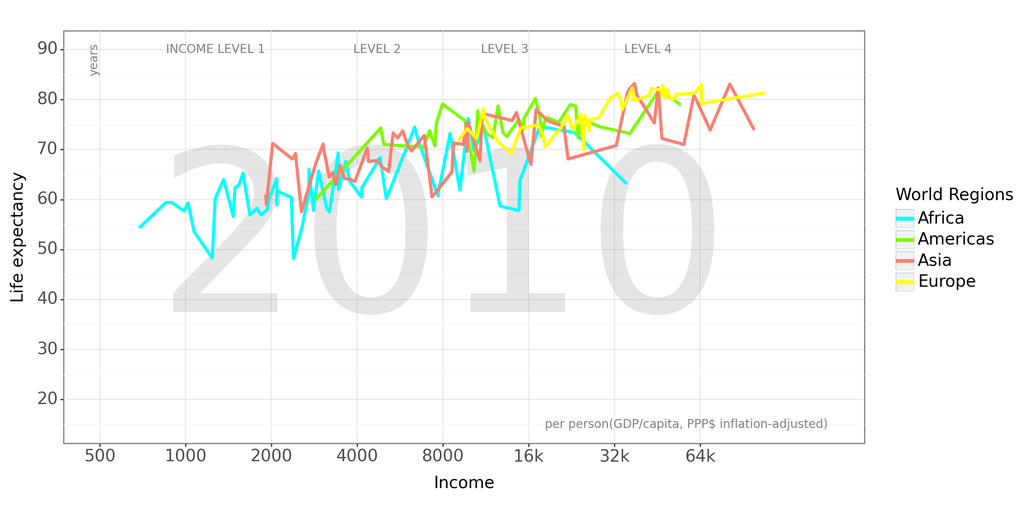

```python
#Creating the line plot and storing it in a object
line_plot = (p9.ggplot(df_q1, mapping = p9.aes(x='income', y='life_exp', color='four_regions'))

             # Annotations specified to add text to the geometry
             + p9.annotate("text", x = 180000, y = 15, label ="per person(GDP/capita, PPP$ inflation-adjusted)", color = "grey", size = 10, ha = "right")
             + p9.annotate("text", x = 500, y = 88, label = "years", color ="grey", size = 10, ha = "right", angle = 90)
             + p9.annotate("text", x = 8000, y = 50, label = "2010", color = "grey", size = 190, alpha = 0.2)
             + p9.annotate("text", x = 1900, y = 90, label = "INCOME LEVEL 1", color = "grey", size = 10, ha = "right")
             + p9.annotate("text", x = 5700, y = 90, label = "LEVEL 2", color = "grey", size = 10, ha = "right")
             + p9.annotate("text", x = 16000, y = 90, label = "LEVEL 3", color = "grey", size = 10, ha = "right")
             + p9.annotate("text", x = 51000, y = 90, label = "LEVEL 4", color = "grey", size = 10, ha = "right")

             # Line plot with size defined for thickness of plot
             + p9.geom_line(size = 1.5)

             # Labels of axes and legend
             + p9.labs(x ='Income', y ='Life expectancy', color ='World Regions')
             + p9.guides(color = p9.guide_legend(title = "World Regions"))


             # Themes and colors specified as well as labels of legend capitalized
             + p9.theme_bw()
             + p9.theme(text = p9.element_text(size = 14), figure_size = (12, 6))
             + p9.scale_color_manual(values = {"africa": "aqua","asia": "salmon","americas": "lawngreen", "europe": "yellow"},
                                     labels = {"africa": "Africa", "asia": "Asia", "americas": "Americas", "europe": "Europe"})

             # Breaks and labels pf x and y axes
             + p9.scale_x_continuous(breaks = [500, 1000, 2000, 4000, 8000, 16000, 32000, 64000],
                                     labels = ["500", "1000", "2000", "4000", "8000", "16k", "32k", "64k"],
                                     trans = 'log', limits = (500, 180000))
             + p9.scale_y_continuous(breaks = [20, 30, 40, 50, 60, 70, 80, 90],
                                     labels = ["20", "30", "40", "50", "60", "70", "80", "90"], limits = (15,90)))

#print/display the lineplot
print(line_plot)
```

## **Task 2**

**Part 1: Identify, and list here, what aesthetics are being used and which variables are being mapped to each aesthetic.**

The following aesthetics are being used: position i.e x and y, size, fill and annotation. In this case, the exports variable is mapped by the x aesthetic, the imports variable is mapped by the y aesthetic, the world’s continents characterized by the four regions variable: Asia, Europe, Africa, and the Americas are mapped by the fill aesthetic. Lastly, the energy variable is mapped by the size aesthetic.

**Part 2: Import the q2data.csv dataset.**

```python
# Import the dataset provided
df_q2 = pd.read_csv("q2data.csv")

# Drop the rows containinng null values
df_q2.dropna(inplace = True)
df_q2
```

|  | imports | exports | energy | year | country | four_regions | six_regions | eight_regions | world_bank_region |
| --- | --- | --- | --- | --- | --- | --- | --- | --- | --- |
| 1 | 36.7 | 11.5 | 427.0 | 1997 | Albania | europe | europe_central_asia | europe_east | Europe & Central Asia |
| 2 | 22.5 | 22.6 | 825.0 | 1997 | Algeria | africa | middle_east_north_africa | africa_north | Middle East & North Africa |
| 6 | 12.9 | 10.4 | 1660.0 | 1997 | Argentina | americas | america | america_south | Latin America & Caribbean |
| 7 | 52.8 | 19.0 | 610.0 | 1997 | Armenia | europe | europe_central_asia | europe_east | Europe & Central Asia |
| 9 | 20.5 | 19.6 | 5550.0 | 1997 | Australia | asia | east_asia_pacific | east_asia_pacific | East Asia & Pacific |
| ... | ... | ... | ... | ... | ... | ... | ... | ... | ... |
| 198 | 22.9 | 22.6 | 2080.0 | 1997 | Uzbekistan | asia | europe_central_asia | asia_west | Europe & Central Asia |
| 200 | 22.7 | 20.9 | 2250.0 | 1997 | Venezuela | americas | america | america_south | Latin America & Caribbean |
| 201 | 52.2 | 44.8 | 340.0 | 1997 | Vietnam | asia | east_asia_pacific | east_asia_pacific | East Asia & Pacific |
| 204 | 31.6 | 24.6 | 617.0 | 1997 | Zambia | africa | sub_saharan_africa | africa_sub_saharan | Sub-Saharan Africa |
| 205 | 45.1 | 43.4 | 845.0 | 1997 | Zimbabwe | africa | sub_saharan_africa | africa_sub_saharan | Sub-Saharan Africa |

127 rows × 9 columns

**Part 3: Recreate the plot as best you can using plotnine.**

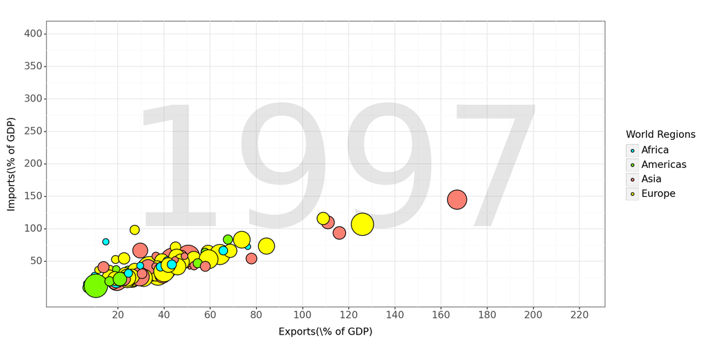

```
<Figure Size: (1200 x 600)>
```

```python
#Creating the scatterplot and storing it in a object
scatterplot2 = (p9.ggplot(df_q2, mapping = p9.aes(x='exports', y='imports', fill ='four_regions', size ='energy'))

        # Annotations specified to add text to the geometry
        + p9.annotate("text", x = 115, y = 175, label = "1997", color = "grey", size = 205, alpha = 0.2)

        # Plot with alpha defined for transparency of points
        + p9.geom_point(alpha = 1)

        + p9.labs(x ='Exports(\% of GDP)', y ='Imports(\% of GDP)', fill ='World Regions', size ='Energy Use')
        + p9.guides(size = False, fill = p9.guide_legend(title = "World Regions"))


        # Themes
        + p9.theme_bw()
        + p9.theme(text = p9.element_text(size = 12), figure_size = (12, 6))
        + p9.scale_fill_manual(values = {"africa": "aqua", "asia": "salmon", "americas": "lawngreen", "europe": "yellow"},
                               labels = {"africa": "Africa", "asia": "Asia", "americas": "Americas", "europe": "Europe"})
        + p9.scale_size(range=(1, 17))

        #Breaks and Labels
        + p9.scale_x_continuous(breaks = [20, 40, 60, 80, 100, 120, 140, 160, 180, 200, 220],
                                labels = ["20", "40", "60", "80", "100", "120", "140", "160", "180", "200", "220"],
                                 limits = (0,220))
        + p9.scale_y_continuous(breaks = [50, 100, 150, 200, 250, 300, 350, 400],
                                labels = ["50", "100", "150", "200", "250", "300", "350", "400"], limits = (0,400))
       )
scatterplot2
```

**Part 4: What other geometries could you use here besides geom_point? Provide an actual plot of another geometry being used here and why it’s good or bad for visualizing these data.**

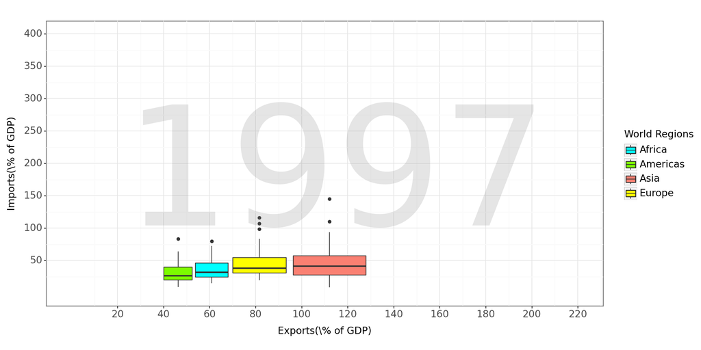

```python
#Creating the boxplot and storing it in a object
box_plot2 = (p9.ggplot(df_q2, mapping = p9.aes(x='exports', y='imports', fill ='four_regions', size ='energy'))

        + p9.geom_boxplot(alpha = 1)

        # Annotations, Labels, Themes ,Guide and color specified to enhance visualization
        + p9.annotate("text", x = 115, y = 175, label = "1997", color = "grey", size = 205, alpha = 0.2)
        + p9.labs(x ='Exports(\% of GDP)', y ='Imports(\% of GDP)', fill ='World Regions', size ='Energy Use')
        + p9.theme_bw()
        + p9.theme(text = p9.element_text(size = 12), figure_size = (12, 6))
        + p9.guides(size = False, fill = p9.guide_legend(title = "World Regions"))
        + p9.scale_fill_manual(values = {"africa": "aqua", "asia": "salmon", "americas": "lawngreen", "europe": "yellow"},
                               labels = {"africa": "Africa", "asia": "Asia", "americas": "Americas", "europe": "Europe"})

        #Breaks and Labels for the axes
        + p9.scale_x_continuous(breaks = [20, 40, 60, 80, 100, 120, 140, 160, 180, 200, 220],
                                labels = ["20", "40", "60", "80", "100", "120", "140", "160", "180", "200", "220"],
                                 limits = (0,220))
        + p9.scale_y_continuous(breaks = [50, 100, 150, 200, 250, 300, 350, 400],
                                labels = ["50", "100", "150", "200", "250", "300", "350", "400"], limits = (0,400)))

#print/display boxplot created
print(box_plot2)
```

# **Task 3**

**Part 1: Identify, and list here, what aesthetics are being used and which variables are being mapped to each aesthetic.**

The following aesthetics are being used: position i.e x and y, size, fill and annotation. In this case, the internet_users variable is mapped by the x aesthetic, the gdp variable is mapped by the y aesthetic, the world’s continents characterized by the four regions variable: Asia, Europe, Africa, and the Americas are mapped by the fill aesthetic. Lastly, the income variable is mapped by the size aesthetic.

**Part 2: Import the q3data.csv dataset.**

```python
# Import the dataset provided
df_q3 = pd.read_csv("q3data.csv")

# Drop the rows containing null values
df_q3.dropna(inplace = True)
df_q3
```

|  | internet_users | gdp | income | year | country | four_regions | six_regions | eight_regions | world_bank_region |
| --- | --- | --- | --- | --- | --- | --- | --- | --- | --- |
| 0 | 0.00456 | 330.0 | 1190.0 | 2001 | Afghanistan | asia | south_asia | asia_west | South Asia |
| 1 | 0.39000 | 2570.0 | 6780.0 | 2001 | Albania | europe | europe_central_asia | europe_east | Europe & Central Asia |
| 2 | 1.59000 | 3770.0 | 9230.0 | 2001 | Algeria | africa | middle_east_north_africa | africa_north | Middle East & North Africa |
| 4 | 11.30000 | 42600.0 | 35600.0 | 2001 | Andorra | europe | europe_central_asia | europe_west | Europe & Central Asia |
| 5 | 0.27000 | 2440.0 | 2900.0 | 2001 | Angola | africa | sub_saharan_africa | africa_sub_saharan | Sub-Saharan Africa |
| ... | ... | ... | ... | ... | ... | ... | ... | ... | ... |
| 209 | 4.91000 | 10800.0 | 14800.0 | 2001 | Venezuela | americas | america | america_south | Latin America & Caribbean |
| 210 | 1.85000 | 847.0 | 3270.0 | 2001 | Vietnam | asia | east_asia_pacific | east_asia_pacific | East Asia & Pacific |
| 212 | 0.51900 | 1190.0 | 4940.0 | 2001 | Yemen | asia | middle_east_north_africa | asia_west | Middle East & North Africa |
| 213 | 0.47800 | 991.0 | 2080.0 | 2001 | Zambia | africa | sub_saharan_africa | africa_sub_saharan | Sub-Saharan Africa |
| 214 | 1.10000 | 1330.0 | 3190.0 | 2001 | Zimbabwe | africa | sub_saharan_africa | africa_sub_saharan | Sub-Saharan Africa |

181 rows × 9 columns

**Part 3: Recreate the plot as best you can using plotnine.**

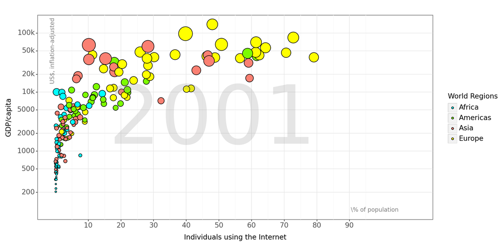

```python
# Creating the scatterplot and storing it in a object
scatter_plot3 = (p9.ggplot(df_q3, mapping = p9.aes(x='internet_users', y='gdp', fill ='four_regions', size ='income'))

        + p9.geom_point(alpha = 1)

        # Annotations specified to add text to the geometry
        + p9.annotate("text", x = 105, y = 100, label ="\% of population", color = "grey", size = 10, ha = "right")
        + p9.annotate("text", x = 0, y = 50000, label = "US$, inflation-adjusted", color ="grey", size = 10, ha = "right", angle = 90)
        + p9.annotate("text", x = 48, y = 3200, label = "2001", color = "grey", size = 140, alpha = 0.2)


        # Labels, Themes, Guide and color specified to enhance visualization
        + p9.labs(x ='Individuals using the Internet', y ='GDP/capita', fill ='World Regions', size ='Income')
        + p9.theme_bw()
        + p9.theme(text = p9.element_text(size = 12), figure_size = (12, 6))
        + p9.guides(size = False, fill = p9.guide_legend(title = "World Regions"))
        + p9.scale_fill_manual(values = {"africa": "aqua", "asia": "salmon", "americas": "lawngreen", "europe": "yellow"},
                               labels = {"africa": "Africa", "asia": "Asia", "americas": "Americas", "europe": "Europe"})
        + p9.scale_size(range=(1, 13))

        # Breaks and Labels specified for each axis
        + p9.scale_x_continuous(breaks = [10, 20, 30, 40, 50, 60, 70, 80, 90],
                                labels = ["10", "20", "30", "40", "50", "60", "70", "80", "90"],
                                 limits = (0,110))
        + p9.scale_y_continuous(breaks = [200, 500, 1000, 2000, 5000, 10000, 20000, 50000,100000],
                                labels = ["200", "500", "1000", "2000", "5000", "10k", "20k", "50k", "100k"],
                                trans = 'log'))

#print/display scatterplot created
print(scatter_plot3)
```

**Part 4: What other geometries could you use here besides geom_point? Provide an actual plot of another geometry being used here and why it’s good or bad for visualizing these data.**

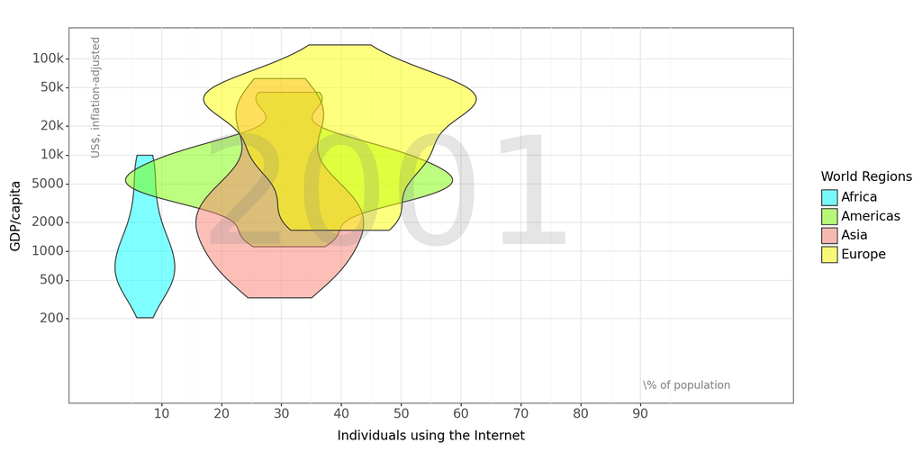

```python
warnings.filterwarnings('ignore')

#Creating the violinplot and storing it in a object
violin_plot3 = (p9.ggplot(df_q3, p9.aes(x='internet_users', y='gdp', fill ='four_regions', size = 'income'))
    + p9.geom_violin(alpha = 0.5, width = 5)

    # Annotations specified to add text to the geometry
    + p9.annotate("text", x = 105, y = 40, label ="\% of population", color = "grey", size = 10, ha = "right", va = "center")
    + p9.annotate("text", x = 0, y = 40000, label = "US$, inflation-adjusted", color ="grey", size = 10, ha = "right", angle = 90)
    + p9.annotate("text", x = 48, y = 3200, label = "2001", color = "grey", size = 140, alpha = 0.2)

    # Labels, Themes, Guide and color specified to enhance visualization
    + p9.labs(x='Individuals using the Internet', y='GDP/capita', fill='World Regions')
    + p9.theme_bw()
    + p9.theme(text = p9.element_text(size = 12), figure_size = (12, 6))
    + p9.scale_fill_manual(values = {"africa": "aqua", "asia": "salmon", "americas": "lawngreen", "europe": "yellow"},
                           labels = {"africa": "Africa", "asia": "Asia", "americas": "Americas", "europe": "Europe"})

    # Breaks and Labels specified for each axis
    + p9.scale_x_continuous(breaks = [10, 20, 30, 40, 50, 60, 70, 80, 90],
                            labels = ["10", "20", "30", "40", "50", "60", "70", "80", "90"],
                            limits = (0,110))

    + p9.scale_y_continuous(breaks = [200, 500, 1000, 2000, 5000, 10000, 20000, 50000,100000],
                            labels = ["200", "500", "1000", "2000", "5000", "10k", "20k", "50k", "100k"],
                            trans = 'log'))
#print/display violinplot created
print(violin_plot3)
```